# Are we more civilized today?

Emma Kristensen Larsen

20 March 2026, 12:34

```r
knitr::opts_chunk$set(echo = TRUE,
                      message=TRUE)
```

# Exploring Homicide rates in NW Europe

In this exercise, you will load a Manuel Eisner’s dataset that captures the developments in homicides from Middle Ages to 20th century.

**Your task: Explore the data and create visualisations as instructed in the script.**

- **Upload to Github this .Rmd file with solutions and its .html knitted version.**
- **Submit to Brightspace a document that follows the template and contains (1) URL of this script and its knitted version in Github, (2) one plot of your choice, and (3) answer of 250 words to the Final Question.**

This exercise is based on the dataset provided by [OurWorldInData project](https://ourworldindata.org/homicides) based at the Oxford University.

## The long-term trend in Homicides in Western Europe

Understanding how homicide rates have changed prior to the modern era requires the help of historians and archivists. Manuel Eisner, a criminology professor at the University of Cambridge, and his colleagues published the Historical Violence Database a compilation of data on long-term trends in homicide rates, in addition to qualitative information such as the cause of death, perpetrator and victim. This database is limited to countries with relatively complete historical records on violence and crime – mainly Western Europe and the US.

Starting in the second half of the nineteenth century, these European regions have consistent police records of those accused of murder or manslaughter and annual counts of homicide victims. To go back further in time, reaching as far back as the thirteenth century, Eisner collected estimates (from historical records of coroner reports, court trials, and the police) of homicide rates made in over ninety publications by scholars.

Homicide rates – measured as the number of homicides per 100,000 individuals – up to 1990 are sourced from Eisner’s (2003) publication and the Historical Violence Database.

Are homicide rates in Europe today lower or higher than in the past? Using the provided dataset, display and describe the long-run homicide rates for the five European regions: Italy, England, Germany, Netherlands and Scandinavia.

```r
library(tidyverse)
```

## Loading the available data from ourworldindata.org

You should always interrogate the source of your data. Who compiled it, from where, what is missing, how representative the data are? Check the data/Metadata.txt to learn about the data provenance.

```r
Western_Europe <- read_csv("data/homicide-rates-across-western-europe.csv")
```

## Inspecting the data

How clean and analysis-ready is the dataset? Do you understand what the column names represent? What is the difference between rate and homicide number?

```r
head(Western_Europe)
```

```
## # A tibble: 6 × 4
##   Entity  Code   Year Homicide rate in Europe over long-term (per 100,000) (ho…¹
##   <chr>   <chr> <dbl>                                                      <dbl>
## 1 England <NA>   1300                                                         23
## 2 England <NA>   1550                                                          7
## 3 England <NA>   1625                                                          6
## 4 England <NA>   1675                                                          4
## 5 England <NA>   1725                                                          2
## 6 England <NA>   1775                                                          1
## # ℹ abbreviated name:
## #   ¹`Homicide rate in Europe over long-term (per 100,000) (homicides per 100,000 people)`
```

Ok, the data look good except for the column `Homicide rate in Europe over long-term (per 100,000)` which is not very easy to work with.

- Use the `names()` function and assignment key to relabel this column to `homicides_per_100k`

```r
# names() function produces the names of columns as a character vector with 4 elements
names(Western_Europe)
```

```
## [1] "Entity"
## [2] "Code"
## [3] "Year"
## [4] "Homicide rate in Europe over long-term (per 100,000) (homicides per 100,000 people)"
```

```r
# If we can select the fourth element, we can also rename it / reassign a name to it
names(Western_Europe)[4] <- "Homicide_rate"
names(Western_Europe)[1] <- "Countries"

# check the new name!
names(Western_Europe)
```

```
## [1] "Countries"     "Code"          "Year"          "Homicide_rate"
```

Now, that you have looked at what the data looks like and what it represents, and streamlined it, let’s see what big picture it contains.

## Viewing the long-term trend in homicides

- use `ggplot()` function and remember the`+` at the end of the line
- chose a meaningful `geom_......()` for geometry (hint: points are not great)
- load `Year` on the `x` axis and `homicides_per_100k` column in y axis
- to color individual country entries consistently, assign the country column to the argument `color`.
- provide meaningful title and axis labels
- remember to change the `eval` flag so that the code chunk renders when knitted

```r
# option 2 - this one starts with the dataset and continues with ggplot()
unique(Western_Europe$Countries)
```

```
## [1] "England"                 "Germany and Switzerland"
## [3] "Italy"                   "Netherlands and Belgium"
## [5] "Scandinavia"
```

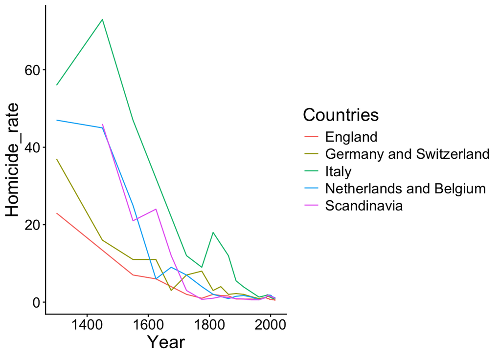

```r
Western_Europe %>%
  ggplot(aes(x= Year, y= Homicide_rate, color=Countries))+
  geom_line()+
  theme_classic()+
  theme(text = element_text(size=18))
```

Alright, the homicide rates should all be descending over time. What a comfort. But the viz is not super clear. Let’s check the rates for individual countries.

## The homicides of individual countries

You can visualize each country’s trend separately by adding an extra argument to the ggplot, the `facet_wrap()` and feeding it the country column. If in doubt, check your ggplot tutorial and your country column name for exact usage.

- reuse the ggplot from the chunk above
- insert `facet_wrap()` after the specification of geometry to split countries in separate charts
- change the facet “layout” to two columns and three rows so that the trends are easier to see in horizontal layout.

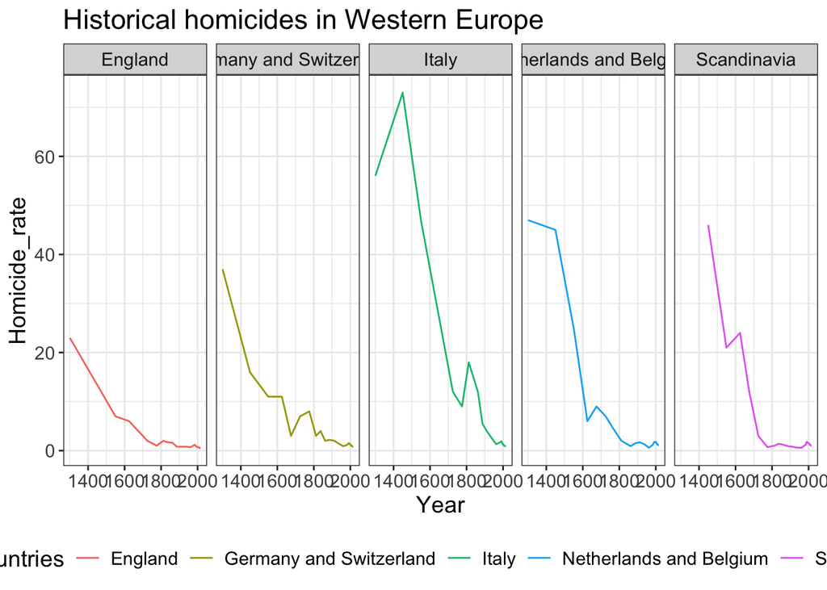

```r
#... YOUR CODE
Western_Europe %>%
  ggplot(aes(x= Year, y= Homicide_rate, color=Countries))+
  geom_line()+
  labs(title = "Historical homicides in Western Europe",
       x="Year",
       y="Homicide_rate") +
  facet_wrap(~ Countries, nrow=1)+
  theme_bw()+
  theme(legend.position = "bottom")+
  theme(text = element_text(size=14))
```

```r
ggsave("homicides1.png", width =14, height =6, dpi= 100)
```

## Comparing the trends in homicide with the pattern of reign duration among Danish rulers through time.

- Load your Danish king dataset. Hopefully it is tidy and your years and duration of reign are all numeric.
- You need to have a consistent way of plotting the rulers’ reign on the x axis, so I recommend you create a midyear column by calculating the middle of each monarch’s rule (Hint: `midyear` = `endyear` - (`endyear`-`startyear`)/2)
- Start a ggplot plotting midyear on x axis and duration on y axis
- Try `geom_smooth()` for geometry
- Provide meaningful labels and a title
- How would you characterize the trend compared to the homicides above?

In the “Historical homicides in Western Europe” plot, the overall trend shows that homicide rates decrease over time. In the “Danish Monarchs” plot, the trend indicates that the duration of kings reigns increases over time. If we assume that shorter reigns were because of a higher risk of being killed, the two visualizations suggest the same pattern. The homicide rates decline and the duration of kings’ reigns increases, because the homicide decrease over time.

```r
# YOUR CODE HERE:
read_csv2("data/Danish_monarchs-kopi.csv")
```

```
## ℹ Using "','" as decimal and "'.'" as grouping mark. Use `read_delim()` for more control.
```

```
## # A tibble: 57 × 5
##    Name         Birth_year Death_year Reign_start Reign_end
##    <chr>             <dbl>      <dbl>       <dbl>     <dbl>
##  1 Frederik_10        1968         NA        2024        NA
##  2 Margrethe_2        1940         NA        1972      2024
##  3 Frederik_9         1899       1972        1947      1972
##  4 Christian_10       1870       1947        1912      1947
##  5 Frederik_8         1843       1912        1906      1912
##  6 Christian_9        1818       1906        1863      1906
##  7 Frederik_7         1808       1863        1848      1863
##  8 Christian_8        1786       1848        1839      1848
##  9 Frederik_6         1768       1839        1808      1839
## 10 Christian_7        1749       1808        1766      1808
## # ℹ 47 more rows
```

```r
kings <- read_csv2("data/Danish_monarchs-kopi.csv")
```

```
## ℹ Using "','" as decimal and "'.'" as grouping mark. Use `read_delim()` for more control.
```

```r
kings
```

```
## # A tibble: 57 × 5
##    Name         Birth_year Death_year Reign_start Reign_end
##    <chr>             <dbl>      <dbl>       <dbl>     <dbl>
##  1 Frederik_10        1968         NA        2024        NA
##  2 Margrethe_2        1940         NA        1972      2024
##  3 Frederik_9         1899       1972        1947      1972
##  4 Christian_10       1870       1947        1912      1947
##  5 Frederik_8         1843       1912        1906      1912
##  6 Christian_9        1818       1906        1863      1906
##  7 Frederik_7         1808       1863        1848      1863
##  8 Christian_8        1786       1848        1839      1848
##  9 Frederik_6         1768       1839        1808      1839
## 10 Christian_7        1749       1808        1766      1808
## # ℹ 47 more rows
```

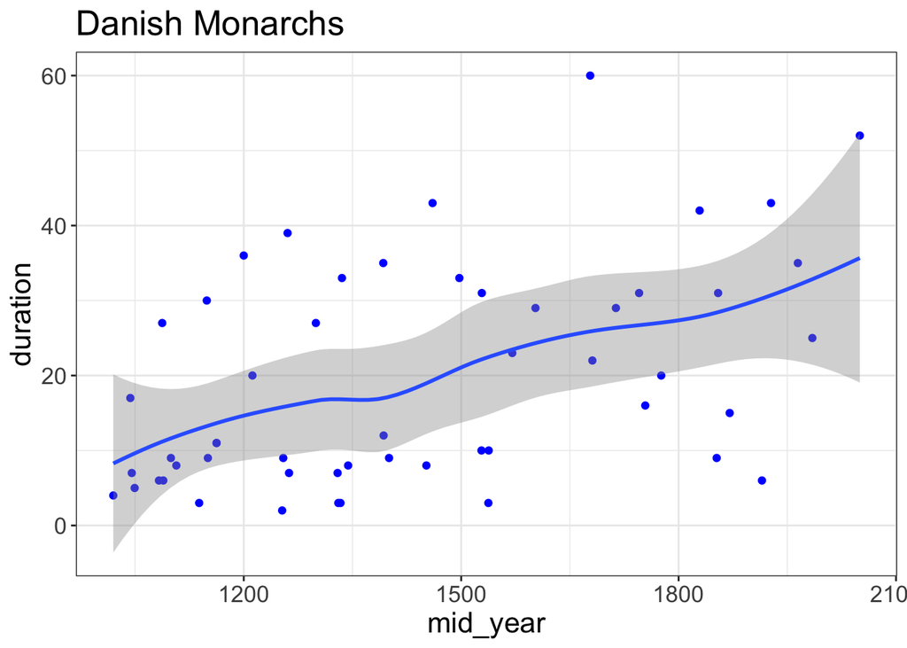

```r
kings %>%
  mutate(duration = Reign_end-Reign_start) %>%
  mutate(mid_year= Reign_end + duration/2) %>%
  ggplot(aes(x = mid_year, y = duration)) +
  geom_point(color = "blue")+
  geom_smooth()+
  labs(title ="Danish Monarchs")+
    theme_bw() +
  theme(text = element_text(size = 16))
```

##Final touches:

1. Plot: In the facetted plot above, move the legend from the current position on the side to below the facets, and label it “Country” instead of “Entity”.
2. Rmarkdown:
- edit the author of the document, and convert ‘Final Tasks’ into heading #2 (like the other headings)
- add a `floating table of contents` to your Rmarkdown document,
- provide informative `chunk-names` and edit flags in your R chunks to `TRUE`, and
- automatically generate a `timestamp` to show when the document was last updated. (Hint: check the Rmarkdown episode in our Data Carpentry tutorial)

## Are we more civilized today?:

*In <250 words articulate your answer on the basis of the data visualisations to the following question*: **are we more civilized today?**

By using the two plots, “Historical homicides in Western Europe” and “Danish Monarchs”, we can reflect on if we have become more civilized over time.

In the “Historical homicides in Western Europe” plot, the trend shows that homicide decrease over time. This suggests that violence has become less common, which is often associated with increased social stability, stronger institutions, and improved legal systems.

In the “Danish Monarchs” plot, the trend indicates that the duration of kings reigns increases over time. Earlier monarchs tend to have shorter reigns, while more recent monarchs rule for longer periods. One possible explanation is that in earlier periods there were more unstable and violets, increasing the risk of being killed in a homicide. As homicide rates decline, the duration of kings’ reigns increases. This suggests a development toward more stable and less violent societies.

The two plots can show that societies have become more civilized over time, because of decreasing violence and increasing stability.